# DATA 621 Assignment 3

Critical Thinking Group 2: George Cruz Deschamps, Karim Hammoud, Maliat Islam, Matthew Lucich, Gabriella Maritnez, Ken Popkin

Date: 2021-10-23 | Due: 2021-11-07

# Binary Logistic Regression

## Overview

In this homework assignment, you will explore, analyze and model a data set containing information on crime for various neighborhoods of a major city. Each record has a response variable indicating whether or not the crime rate is above the median crime rate (1) or not (0).

Your objective is to build three different binary logistic regression models on the training data set to predict whether or not neighborhoods are at risk for high crime. You will provide classifications and probabilities for the evaluation data set using your binary logistic regression model. You can only use the variables given to you (or variables that you derive from the variables provided). Below is a short description of the variables of interest in the data set:

- `zn` proportion of residential land zoned for lots over 25,000 sq.ft.
- `indus` proportion of non-retail business acres per town
- `chas` Charles River dummy variable (= 1 if tract bounds river; 0 otherwise)
- `nox` nitrogen oxides concentration (parts per 10 million)
- `rm` average number of rooms per dwelling
- `age` proportion of owner-occupied units built prior to 1940
- `dis` weighted distances to five Boston employment centers
- `rad` index of accessibility to radial highways
- `tax` full-value property-tax rate per $10,000
- `ptratio` pupil-teacher ratio by town
- `lstat` % lower status of the population
- `medv` median value of owner-occupied homes in $1000’s
- `target` indicating whether or not the crime rate is above the median crime rate (1) or not (0) **response variable**

## Package Dependencies

```r
library(tidyverse)
library(Hmisc)
library(psych)
library(corrplot)
library(RColorBrewer)
library(knitr)
library(MASS)
library(caret)
library(kableExtra)
library(ResourceSelection)
library(pROC)
library(Amelia)
library(summarytools)
library(DataExplorer)
library(knitr)
library(dplyr)
```

# Data Exploration

```r
#load data
crime_train <- read.csv("https://raw.githubusercontent.com/akarimhammoud/Data_621/main/Assignment_3/data/crime-training-data_modified.csv")
crime_test <- read.csv("https://raw.githubusercontent.com/akarimhammoud/Data_621/main/Assignment_3/data/crime-evaluation-data_modified.csv")
```

Exploratory data analysis is the process to get to know your data, so that a hypothesis can be generated and later tested. Visualization techniques are usually applied to aid the exploration of the data.

To get introduced to the dataset, we use DataExplorer’s `introduce()` function:

```r
kable(t(introduce(crime_train)), row.names = TRUE, col.names = "", format.args = list(big.mark = ","))
```

| rows | 466 |
| --- | --- |
| columns | 13 |
| discrete_columns | 0 |
| continuous_columns | 13 |
| all_missing_columns | 0 |
| total_missing_values | 0 |
| complete_rows | 466 |
| total_observations | 6,058 |
| memory_usage | 44,440 |

Using dplyr’s `glimpse()`[^1] function, we can take a “glimpse” into the both the `crime_train` and `crime_test` data respectively, and easily see the dimensions, variable names and types.

```r
glimpse(crime_train)
```

```
## Rows: 466
## Columns: 13
## $ zn      <dbl> 0, 0, 0, 30, 0, 0, 0, 0, 0, 80, 22, 0, 0, 22, 0, 0, 100, 20...
## $ indus   <dbl> 19.58, 19.58, 18.10, 4.93, 2.46, 8.56, 18.10, 18.10, 5.19, ...
## $ chas    <int> 0, 1, 0, 0, 0, 0, 0, 0, 0, 0, 0, 0, 0, 0, 0, 0, 0, 0, 0, 0,...
## $ nox     <dbl> 0.605, 0.871, 0.740, 0.428, 0.488, 0.520, 0.693, 0.693, 0.5...
## $ rm      <dbl> 7.929, 5.403, 6.485, 6.393, 7.155, 6.781, 5.453, 4.519, 6.3...
## $ age     <dbl> 96.2, 100.0, 100.0, 7.8, 92.2, 71.3, 100.0, 100.0, 38.1, 19...
## $ dis     <dbl> 2.0459, 1.3216, 1.9784, 7.0355, 2.7006, 2.8561, 1.4896, 1.6...
## $ rad     <int> 5, 5, 24, 6, 3, 5, 24, 24, 5, 1, 7, 5, 24, 7, 3, 3, 5, 5, 2...
## $ tax     <int> 403, 403, 666, 300, 193, 384, 666, 666, 224, 315, 330, 398,...
## $ ptratio <dbl> 14.7, 14.7, 20.2, 16.6, 17.8, 20.9, 20.2, 20.2, 20.2, 16.4,...
## $ lstat   <dbl> 3.70, 26.82, 18.85, 5.19, 4.82, 7.67, 30.59, 36.98, 5.68, 9...
## $ medv    <dbl> 50.0, 13.4, 15.4, 23.7, 37.9, 26.5, 5.0, 7.0, 22.2, 20.9, 2...
## $ target  <int> 1, 1, 1, 0, 0, 0, 1, 1, 0, 0, 0, 0, 1, 1, 0, 0, 0, 1, 1, 1,...
```

```r
glimpse(crime_test)
```

```
## Rows: 40
## Columns: 12
## $ zn      <int> 0, 0, 0, 0, 0, 25, 25, 0, 0, 0, 0, 0, 0, 0, 0, 0, 0, 0, 22,...
## $ indus   <dbl> 7.07, 8.14, 8.14, 8.14, 5.96, 5.13, 5.13, 4.49, 4.49, 2.89,...
## $ chas    <int> 0, 0, 0, 0, 0, 0, 0, 0, 0, 0, 0, 0, 0, 0, 0, 1, 0, 0, 0, 0,...
## $ nox     <dbl> 0.469, 0.538, 0.538, 0.538, 0.499, 0.453, 0.453, 0.449, 0.4...
## $ rm      <dbl> 7.185, 6.096, 6.495, 5.950, 5.850, 5.741, 5.966, 6.630, 6.1...
## $ age     <dbl> 61.1, 84.5, 94.4, 82.0, 41.5, 66.2, 93.4, 56.1, 56.8, 69.6,...
## $ dis     <dbl> 4.9671, 4.4619, 4.4547, 3.9900, 3.9342, 7.2254, 6.8185, 4.4...
## $ rad     <int> 2, 4, 4, 4, 5, 8, 8, 3, 3, 2, 2, 2, 4, 5, 5, 4, 8, 8, 7, 1,...
## $ tax     <int> 242, 307, 307, 307, 279, 284, 284, 247, 247, 276, 188, 188,...
## $ ptratio <dbl> 17.8, 21.0, 21.0, 21.0, 19.2, 19.7, 19.7, 18.5, 18.5, 18.0,...
## $ lstat   <dbl> 4.03, 10.26, 12.80, 27.71, 8.77, 13.15, 14.44, 6.53, 8.44, ...
## $ medv    <dbl> 34.7, 18.2, 18.4, 13.2, 21.0, 18.7, 16.0, 26.6, 22.2, 21.4,...
```

Next, we proceed with our exploratory data analysis by providing univariate descriptive statistics on our training dataset, `crime_train`.

```r
descr(crime_train,
  headings = FALSE, #remove headings#
  transpose = TRUE #allows for better display due to large amount of variables
  ) %>%
  kbl(caption = "Univariate Descriptive Statistics - Training Data Set") %>%
  kable_styling(bootstrap_options = c("striped", "hover", "condensed"))
```

Univariate Descriptive Statistics - Training Data Set

|  | Mean | Std.Dev | Min | Q1 | Median | Q3 | Max | MAD | IQR | CV | Skewness | SE.Skewness | Kurtosis | N.Valid | Pct.Valid |
| --- | --- | --- | --- | --- | --- | --- | --- | --- | --- | --- | --- | --- | --- | --- | --- |
| age | 68.3675966 | 28.3213784 | 2.9000 | 43.7000 | 77.15000 | 94.1000 | 100.0000 | 30.0226500 | 50.225000 | 0.4142515 | -0.5777075 | 0.1131074 | -1.0098814 | 466 | 100 |
| chas | 0.0708155 | 0.2567920 | 0.0000 | 0.0000 | 0.00000 | 0.0000 | 1.0000 | 0.0000000 | 0.000000 | 3.6262142 | 3.3354899 | 0.1131074 | 9.1451313 | 466 | 100 |
| dis | 3.7956929 | 2.1069496 | 1.1296 | 2.1007 | 3.19095 | 5.2146 | 12.1265 | 1.9144814 | 3.113175 | 0.5550896 | 0.9988926 | 0.1131074 | 0.4719679 | 466 | 100 |
| indus | 11.1050215 | 6.8458549 | 0.4600 | 5.1300 | 9.69000 | 18.1000 | 27.7400 | 9.3403800 | 12.955000 | 0.6164648 | 0.2885450 | 0.1131074 | -1.2432132 | 466 | 100 |
| lstat | 12.6314592 | 7.1018907 | 1.7300 | 7.0100 | 11.35000 | 16.9400 | 37.9700 | 7.0720020 | 9.887500 | 0.5622383 | 0.9055864 | 0.1131074 | 0.5033688 | 466 | 100 |
| medv | 22.5892704 | 9.2396814 | 5.0000 | 17.0000 | 21.20000 | 25.0000 | 50.0000 | 6.0045300 | 7.975000 | 0.4090297 | 1.0766920 | 0.1131074 | 1.3737825 | 466 | 100 |
| nox | 0.5543105 | 0.1166667 | 0.3890 | 0.4480 | 0.53800 | 0.6240 | 0.8710 | 0.1334340 | 0.176000 | 0.2104717 | 0.7463281 | 0.1131074 | -0.0357736 | 466 | 100 |
| ptratio | 18.3984979 | 2.1968447 | 12.6000 | 16.9000 | 18.90000 | 20.2000 | 22.0000 | 1.9273800 | 3.300000 | 0.1194035 | -0.7542681 | 0.1131074 | -0.4003627 | 466 | 100 |
| rad | 9.5300429 | 8.6859272 | 1.0000 | 4.0000 | 5.00000 | 24.0000 | 24.0000 | 1.4826000 | 20.000000 | 0.9114258 | 1.0102788 | 0.1131074 | -0.8619110 | 466 | 100 |
| rm | 6.2906738 | 0.7048513 | 3.8630 | 5.8870 | 6.21000 | 6.6300 | 8.7800 | 0.5166861 | 0.742500 | 0.1120470 | 0.4793202 | 0.1131074 | 1.5424378 | 466 | 100 |
| target | 0.4914163 | 0.5004636 | 0.0000 | 0.0000 | 0.00000 | 1.0000 | 1.0000 | 0.0000000 | 1.000000 | 1.0184106 | 0.0342293 | 0.1131074 | -2.0031131 | 466 | 100 |
| tax | 409.5021459 | 167.9000887 | 187.0000 | 281.0000 | 334.50000 | 666.0000 | 711.0000 | 104.5233000 | 385.000000 | 0.4100103 | 0.6593136 | 0.1131074 | -1.1480456 | 466 | 100 |
| zn | 11.5772532 | 23.3646511 | 0.0000 | 0.0000 | 0.00000 | 17.5000 | 100.0000 | 0.0000000 | 16.250000 | 2.0181515 | 2.1768152 | 0.1131074 | 3.8135765 | 466 | 100 |

Furthermore, in the histogram plot below, we see that `medv`, and `rm` are normally distributed. We also note bi-modal distribution of the variables `indus`, `rad` and `tax`. The rest of the variables show moderate to high skewness on either side respectively.

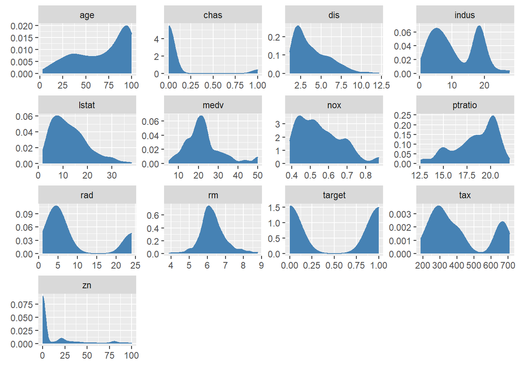

```r
# distribution of the varaibles
crime_train %>%
  gather(variable, value, zn:target) %>%
  ggplot(., aes(value)) +
  geom_density(fill = "steelblue", color="steelblue") +
  facet_wrap(~variable, scales ="free", ncol = 4) +
  labs(x = element_blank(), y = element_blank())
```

In the box-plot figure below, we see many variables exhibit outliers We also see very high interquartile range for `rad` and `tax` variables where crime rate is above the median. Lastly, the variance between the 2 values of target differs for `zn`, `nox`, `age`, `dis`, `rad` & `tax`, which indicates that we will want to consider adding quadratic terms for them.

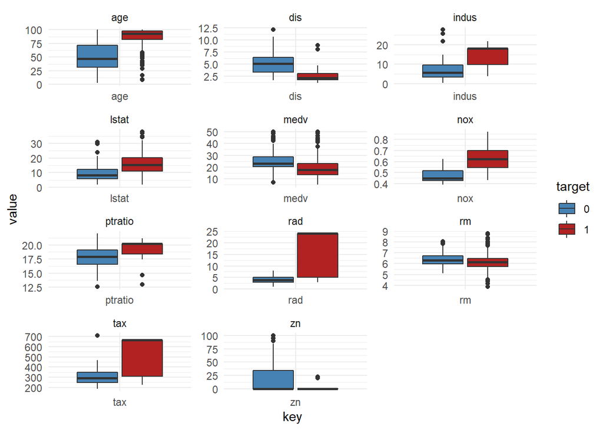

```r
crime_train %>%
  dplyr::select(-chas) %>%
  gather(key, value, -target) %>%
  mutate(key = factor(key),
         target = factor(target)) %>%
  ggplot(aes(x = key, y = value)) +
  geom_boxplot(aes(fill = target)) +
  facet_wrap(~ key, scales = 'free', ncol = 3) +
  scale_fill_manual(values=c("steelblue", "firebrick")) +
  theme_minimal()
```

In order to investigate if there is existing correlation between the data and the target variable, we obtain the values of correlation as well as a visualization.

The correlation table and plot below, we see moderate positive correlation between variables `nox`, `age`, `rad`, `tax`, `indus` and `target` variables; and moderate negative correlation between variable dis. And the rest of the variables have weak or no correlations.

```r
kable(sort(cor(dplyr::select(crime_train, target, everything()))[,1], decreasing = T), col.names = c("Correlation")) %>%
  kable_styling(full_width = F)
```

|  | Correlation |
| --- | --- |
| target | 1.0000000 |
| nox | 0.7261062 |
| age | 0.6301062 |
| rad | 0.6281049 |
| tax | 0.6111133 |
| indus | 0.6048507 |
| lstat | 0.4691270 |
| ptratio | 0.2508489 |
| chas | 0.0800419 |
| rm | -0.1525533 |
| medv | -0.2705507 |
| zn | -0.4316818 |
| dis | -0.6186731 |

Below is a correlation matrix of the feature variables in our dataset. The correlation matrix confirms that multicollinearity is a concern.

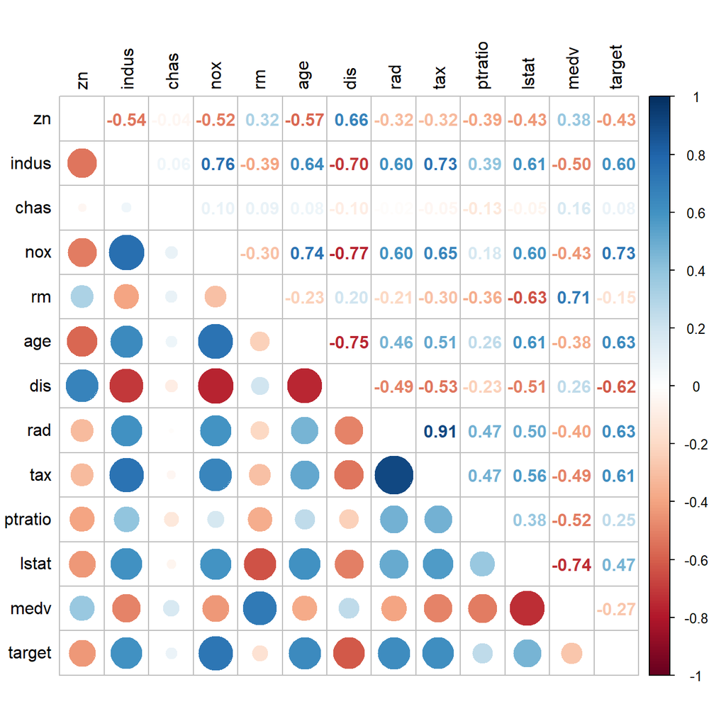

```r
numeric_values <- crime_train %>% select_if(is.numeric)
train_cor <- cor(numeric_values)
corrplot.mixed(train_cor, tl.col = 'black', tl.pos = 'lt', upper = "number", lower="circle")
```

Lastly, we proceed to check if there are any missing data points in the `crime_train`

```r
map(crime_train, ~sum(is.na(.))) %>% t()
```

```
##      zn indus chas nox rm age dis rad tax ptratio lstat medv target
## [1,] 0  0     0    0   0  0   0   0   0   0       0     0    0
```

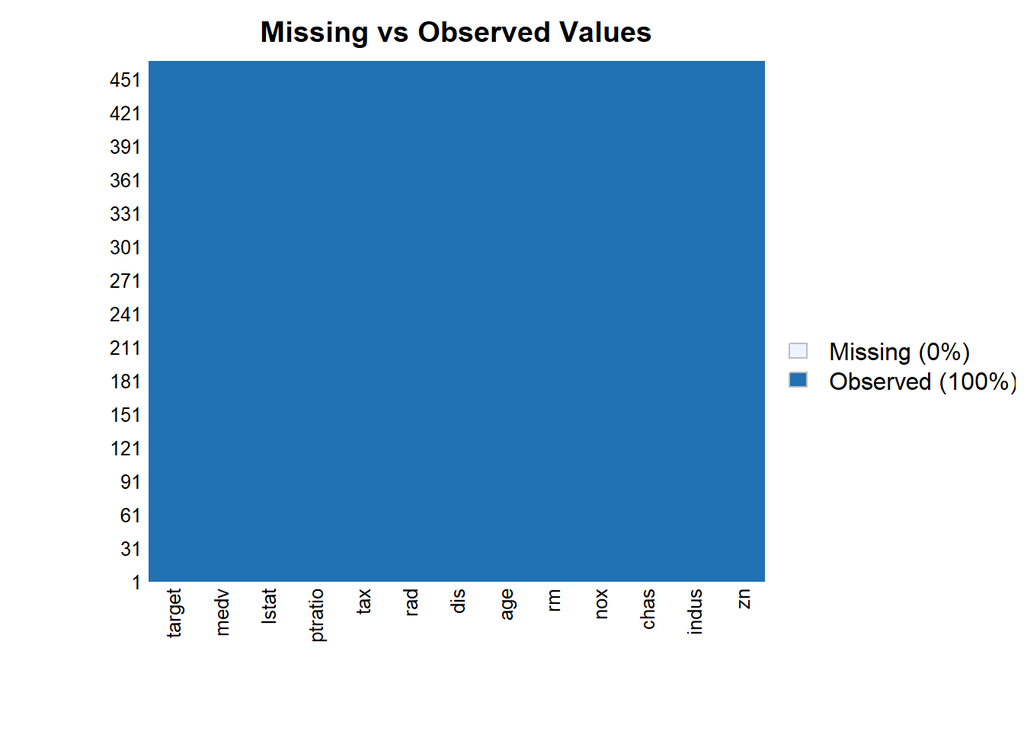

```r
missmap(crime_train, main = "Missing vs Observed Values")
```

# Data Preparation

**Feature Engineering**  
In an effort to fine tune our model, we will introduce the use of feature engineering on select variables.

```r
#make a copy of original dataset
train <- crime_train

#convert chas and target to factors
train$chas <- as.factor(train$chas)
train$target <- as.factor(train$target)

#add new variables
train$ptratio_indicator <- as.factor(ifelse(train$ptratio < 16, 1, 0))
train$lstat_indicator <- as.factor(ifelse(train$lstat < 15, 1, 0))
train$dis_indicator <- as.factor(ifelse(train$dis < 4, 1, 0))
train$age_greater_than_77 <- as.factor(ifelse(train$age >= 77, 1, 0)) #median age is 77
```

```r
str(train)
```

```
## 'data.frame':    466 obs. of  17 variables:
##  $ zn                 : num  0 0 0 30 0 0 0 0 0 80 ...
##  $ indus              : num  19.58 19.58 18.1 4.93 2.46 ...
##  $ chas               : Factor w/ 2 levels "0","1": 1 2 1 1 1 1 1 1 1 1 ...
##  $ nox                : num  0.605 0.871 0.74 0.428 0.488 0.52 0.693 0.693 0.515 0.392 ...
##  $ rm                 : num  7.93 5.4 6.49 6.39 7.16 ...
##  $ age                : num  96.2 100 100 7.8 92.2 71.3 100 100 38.1 19.1 ...
##  $ dis                : num  2.05 1.32 1.98 7.04 2.7 ...
##  $ rad                : int  5 5 24 6 3 5 24 24 5 1 ...
##  $ tax                : int  403 403 666 300 193 384 666 666 224 315 ...
##  $ ptratio            : num  14.7 14.7 20.2 16.6 17.8 20.9 20.2 20.2 20.2 16.4 ...
##  $ lstat              : num  3.7 26.82 18.85 5.19 4.82 ...
##  $ medv               : num  50 13.4 15.4 23.7 37.9 26.5 5 7 22.2 20.9 ...
##  $ target             : Factor w/ 2 levels "0","1": 2 2 2 1 1 1 2 2 1 1 ...
##  $ ptratio_indicator  : Factor w/ 2 levels "0","1": 2 2 1 1 1 1 1 1 1 1 ...
##  $ lstat_indicator    : Factor w/ 2 levels "0","1": 2 1 1 2 2 2 1 1 2 2 ...
##  $ dis_indicator      : Factor w/ 2 levels "0","1": 2 2 2 1 2 2 2 2 1 1 ...
##  $ age_greater_than_77: Factor w/ 2 levels "0","1": 2 2 2 1 2 1 2 2 1 1 ...
```

**Data Transformation** Some of the variables are skewed, have outliers or follow a bi-modal distribution. Therefore, we will perform transformation on some of these variables. First, we will remove the variable `tax` due to multicollinearity and it’s high VIF score. Next, we will take log() transformation of `age` and `lstat` variables to lower skewness. Lastly, we will add quadratic term to `zn`, `rad`, and `nox` variables to account for its variances with respect to target variable.

```r
#MI find multicollinear variables
kable((car::vif(glm(target ~. , data = crime_train))), col.names = c("VIF Score")) %>%  #remove tax for high vif score
  kable_styling(full_width = F)
```

|  | VIF Score |
| --- | --- |
| zn | 2.324259 |
| indus | 4.120699 |
| chas | 1.090265 |
| nox | 4.505049 |
| rm | 2.354788 |
| age | 3.134015 |
| dis | 4.240618 |
| rad | 6.781354 |
| tax | 9.217228 |
| ptratio | 2.013109 |
| lstat | 3.649059 |
| medv | 3.667370 |

```r
# MI transformation of the variables.
trans_train <- train %>%
  dplyr::select(-tax) %>%
  mutate(age = log(age),
         lstat = log(lstat),
         zn = zn^2,
         rad = rad^2,
         nox = I(nox^2))
```

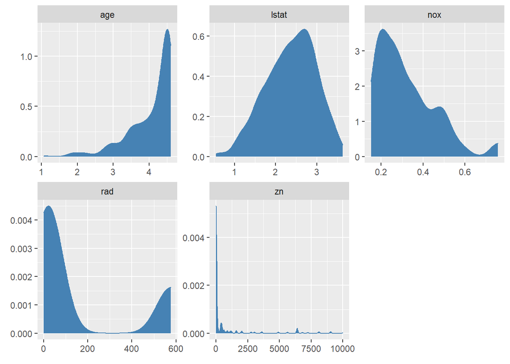

```r
# MI histogram distribution of the transformed variables
trans_train %>%
  gather(key, value, c(age, lstat, zn, rad, nox)) %>%
  ggplot(., aes(value)) +
  geom_density(fill = "steelblue", color="steelblue") +
  facet_wrap(~ key, scales = 'free', ncol = 3) +
  labs(x = element_blank(), y = element_blank())
```

```r
str(trans_train)
```

```
## 'data.frame':    466 obs. of  16 variables:
##  $ zn                 : num  0 0 0 900 0 0 0 0 0 6400 ...
##  $ indus              : num  19.58 19.58 18.1 4.93 2.46 ...
##  $ chas               : Factor w/ 2 levels "0","1": 1 2 1 1 1 1 1 1 1 1 ...
##  $ nox                : 'AsIs' num  0.366025 0.758641   0.5476 0.183184 0.238144 ...
##  $ rm                 : num  7.93 5.4 6.49 6.39 7.16 ...
##  $ age                : num  4.57 4.61 4.61 2.05 4.52 ...
##  $ dis                : num  2.05 1.32 1.98 7.04 2.7 ...
##  $ rad                : num  25 25 576 36 9 25 576 576 25 1 ...
##  $ ptratio            : num  14.7 14.7 20.2 16.6 17.8 20.9 20.2 20.2 20.2 16.4 ...
##  $ lstat              : num  1.31 3.29 2.94 1.65 1.57 ...
##  $ medv               : num  50 13.4 15.4 23.7 37.9 26.5 5 7 22.2 20.9 ...
##  $ target             : Factor w/ 2 levels "0","1": 2 2 2 1 1 1 2 2 1 1 ...
##  $ ptratio_indicator  : Factor w/ 2 levels "0","1": 2 2 1 1 1 1 1 1 1 1 ...
##  $ lstat_indicator    : Factor w/ 2 levels "0","1": 2 1 1 2 2 2 1 1 2 2 ...
##  $ dis_indicator      : Factor w/ 2 levels "0","1": 2 2 2 1 2 2 2 2 1 1 ...
##  $ age_greater_than_77: Factor w/ 2 levels "0","1": 2 2 2 1 2 1 2 2 1 1 ...
```

# Build Models

First, we begin by building the null binary regression model. We will use this model to compare it to the subsequent models we build.

Coefficients for the null or Intercept only model:

```r
null_model <- glm(target~1,data=train, family="binomial"(link = "logit"))
summary(null_model)
```

```
##
## Call:
## glm(formula = target ~ 1, family = binomial(link = "logit"),
##     data = train)
##
## Deviance Residuals:
##    Min      1Q  Median      3Q     Max
## -1.163  -1.163  -1.163   1.192   1.192
##
## Coefficients:
##             Estimate Std. Error z value Pr(>|z|)
## (Intercept) -0.03434    0.09266  -0.371    0.711
##
## (Dispersion parameter for binomial family taken to be 1)
##
##     Null deviance: 645.88  on 465  degrees of freedom
## Residual deviance: 645.88  on 465  degrees of freedom
## AIC: 647.88
##
## Number of Fisher Scoring iterations: 3
```

Next we proceed to make our first model using the both the original, untransformed variables and the engineered features.

```r
model_1 <- glm(target~., family = "binomial"(link = "logit"), data = train)

summary(model_1)
```

```
##
## Call:
## glm(formula = target ~ ., family = binomial(link = "logit"),
##     data = train)
##
## Deviance Residuals:
##     Min       1Q   Median       3Q      Max
## -1.8917  -0.1328  -0.0010   0.0024   3.5163
##
## Coefficients:
##                        Estimate Std. Error z value Pr(>|z|)
## (Intercept)          -42.873132   7.814964  -5.486 4.11e-08 ***
## zn                    -0.078825   0.038257  -2.060 0.039360 *
## indus                 -0.062726   0.049280  -1.273 0.203072
## chas1                  1.059049   0.763475   1.387 0.165398
## nox                   44.583700   8.718567   5.114 3.16e-07 ***
## rm                    -0.567530   0.745600  -0.761 0.446555
## age                    0.019072   0.018456   1.033 0.301411
## dis                    0.666568   0.327609   2.035 0.041887 *
## rad                    0.745172   0.177312   4.203 2.64e-05 ***
## tax                   -0.007360   0.003288  -2.238 0.025213 *
## ptratio                0.626502   0.188187   3.329 0.000871 ***
## lstat                  0.078997   0.075812   1.042 0.297405
## medv                   0.181089   0.071225   2.543 0.011006 *
## ptratio_indicator1     1.803413   1.156048   1.560 0.118764
## lstat_indicator1       0.492508   0.686231   0.718 0.472942
## dis_indicator1         0.296323   0.734391   0.403 0.686584
## age_greater_than_771   0.655696   0.683259   0.960 0.337226
## ---
## Signif. codes:  0 '***' 0.001 '**' 0.01 '*' 0.05 '.' 0.1 ' ' 1
##
## (Dispersion parameter for binomial family taken to be 1)
##
##     Null deviance: 645.88  on 465  degrees of freedom
## Residual deviance: 187.56  on 449  degrees of freedom
## AIC: 221.56
##
## Number of Fisher Scoring iterations: 9
```

Confidence intervals for the regression coefficients:

```r
confint.default(model_1)
```

```
##                             2.5 %        97.5 %
## (Intercept)          -58.19018108 -27.556083221
## zn                    -0.15380693  -0.003842606
## indus                 -0.15931427   0.033861437
## chas1                 -0.43733469   2.555432086
## nox                   27.49562301  61.671777219
## rm                    -2.02887961   0.893820505
## age                   -0.01710002   0.055244413
## dis                    0.02446530   1.308670937
## rad                    0.39764649   1.092698161
## tax                   -0.01380474  -0.000914667
## ptratio                0.25766289   0.995341208
## lstat                 -0.06959190   0.227586891
## medv                   0.04149092   0.320686330
## ptratio_indicator1    -0.46239913   4.069225818
## lstat_indicator1      -0.85247956   1.837495043
## dis_indicator1        -1.14305613   1.735703034
## age_greater_than_771  -0.68346653   1.994858485
```

```r
exp(cbind(OR=coef(model_1), confint.default(model_1)))
```

```
##                                OR        2.5 %       97.5 %
## (Intercept)          2.401238e-19 5.349651e-26 1.077817e-12
## zn                   9.242019e-01 8.574376e-01 9.961648e-01
## indus                9.392004e-01 8.527283e-01 1.034441e+00
## chas1                2.883626e+00 6.457553e-01 1.287686e+01
## nox                  2.303854e+19 8.733682e+11 6.077326e+26
## rm                   5.669243e-01 1.314828e-01 2.444451e+00
## age                  1.019255e+00 9.830454e-01 1.056799e+00
## dis                  1.947542e+00 1.024767e+00 3.701251e+00
## rad                  2.106804e+00 1.488318e+00 2.982310e+00
## tax                  9.926673e-01 9.862901e-01 9.990858e-01
## ptratio              1.871054e+00 1.293903e+00 2.705647e+00
## lstat                1.082202e+00 9.327744e-01 1.255567e+00
## medv                 1.198521e+00 1.042364e+00 1.378073e+00
## ptratio_indicator1   6.070332e+00 6.297709e-01 5.851165e+01
## lstat_indicator1     1.636415e+00 4.263564e-01 6.280785e+00
## dis_indicator1       1.344905e+00 3.188431e-01 5.672915e+00
## age_greater_than_771 1.926483e+00 5.048638e-01 7.351163e+00
```

The odds ratio would indicate the multiplicative change in odds of crime for every one unit increase on a predictor variable.  
Odds-ratios for coefficients:

```r
exp(coef(model_1))
```

```
##          (Intercept)                   zn                indus
##         2.401238e-19         9.242019e-01         9.392004e-01
##                chas1                  nox                   rm
##         2.883626e+00         2.303854e+19         5.669243e-01
##                  age                  dis                  rad
##         1.019255e+00         1.947542e+00         2.106804e+00
##                  tax              ptratio                lstat
##         9.926673e-01         1.871054e+00         1.082202e+00
##                 medv   ptratio_indicator1     lstat_indicator1
##         1.198521e+00         6.070332e+00         1.636415e+00
##       dis_indicator1 age_greater_than_771
##         1.344905e+00         1.926483e+00
```

For our second model, we will use the `trans_train` dataset which includes the transformed variables in the previous section in addition to the engineered features.

```r
model_2 <- glm(target~ .,family = binomial(link = "logit"), data = trans_train)
summary(model_2)
```

```
##
## Call:
## glm(formula = target ~ ., family = binomial(link = "logit"),
##     data = trans_train)
##
## Deviance Residuals:
##     Min       1Q   Median       3Q      Max
## -2.0936  -0.1954   0.0000   0.0000   3.3461
##
## Coefficients:
##                        Estimate Std. Error z value Pr(>|z|)
## (Intercept)          -24.446684   6.912815  -3.536 0.000406 ***
## zn                    -0.003352   0.001694  -1.979 0.047854 *
## indus                 -0.131736   0.049064  -2.685 0.007254 **
## chas1                  1.556410   0.761120   2.045 0.040865 *
## nox                   41.581269   7.974850   5.214 1.85e-07 ***
## rm                    -0.842981   0.697236  -1.209 0.226650
## age                   -0.038224   0.667053  -0.057 0.954304
## dis                    0.571657   0.301933   1.893 0.058315 .
## rad                    0.055708   0.013966   3.989 6.64e-05 ***
## ptratio                0.535961   0.176198   3.042 0.002352 **
## lstat                  0.164198   0.799817   0.205 0.837342
## medv                   0.177604   0.064275   2.763 0.005724 **
## ptratio_indicator1     1.408573   1.082973   1.301 0.193377
## lstat_indicator1       0.066430   0.565626   0.117 0.906507
## dis_indicator1         0.004908   0.720640   0.007 0.994566
## age_greater_than_771   1.342623   0.565052   2.376 0.017497 *
## ---
## Signif. codes:  0 '***' 0.001 '**' 0.01 '*' 0.05 '.' 0.1 ' ' 1
##
## (Dispersion parameter for binomial family taken to be 1)
##
##     Null deviance: 645.88  on 465  degrees of freedom
## Residual deviance: 195.16  on 450  degrees of freedom
## AIC: 227.16
##
## Number of Fisher Scoring iterations: 10
```

For our third model:

```r
trans_train_mod_3 <- trans_train %>%
  dplyr::select(1:12)

model_3 <- glm(target ~ . -rm -chas - age -indus,
             family = binomial(link = "logit"),
             trans_train_mod_3)
summary(model_3)
```

```
##
## Call:
## glm(formula = target ~ . - rm - chas - age - indus, family = binomial(link = "logit"),
##     data = trans_train_mod_3)
##
## Deviance Residuals:
##     Min       1Q   Median       3Q      Max
## -2.1908  -0.2806   0.0000   0.0000   3.0407
##
## Coefficients:
##               Estimate Std. Error z value Pr(>|z|)
## (Intercept) -22.812101   4.437941  -5.140 2.74e-07 ***
## zn           -0.003397   0.001442  -2.355  0.01850 *
## nox          34.818425   5.399202   6.449 1.13e-10 ***
## dis           0.554423   0.190879   2.905  0.00368 **
## rad           0.052140   0.011910   4.378 1.20e-05 ***
## ptratio       0.236630   0.099364   2.381  0.01724 *
## lstat         0.750120   0.560658   1.338  0.18092
## medv          0.133242   0.042226   3.155  0.00160 **
## ---
## Signif. codes:  0 '***' 0.001 '**' 0.01 '*' 0.05 '.' 0.1 ' ' 1
##
## (Dispersion parameter for binomial family taken to be 1)
##
##     Null deviance: 645.88  on 465  degrees of freedom
## Residual deviance: 215.94  on 458  degrees of freedom
## AIC: 231.94
##
## Number of Fisher Scoring iterations: 10
```

# Select Models

To determine if the models produced have significant improvement in fit over the null model, we make use of the `anova()` function.

```r
anova(null_model,model_1,model_2,model_3,test="LRT")
```

```
## Analysis of Deviance Table
##
## Model 1: target ~ 1
## Model 2: target ~ zn + indus + chas + nox + rm + age + dis + rad + tax +
##     ptratio + lstat + medv + ptratio_indicator + lstat_indicator +
##     dis_indicator + age_greater_than_77
## Model 3: target ~ zn + indus + chas + nox + rm + age + dis + rad + ptratio +
##     lstat + medv + ptratio_indicator + lstat_indicator + dis_indicator +
##     age_greater_than_77
## Model 4: target ~ (zn + indus + chas + nox + rm + age + dis + rad + ptratio +
##     lstat + medv) - rm - chas - age - indus
##   Resid. Df Resid. Dev Df Deviance  Pr(>Chi)
## 1       465     645.88
## 2       449     187.56 16   458.32 < 2.2e-16 ***
## 3       450     195.16 -1    -7.60  0.005845 **
## 4       458     215.94 -8   -20.78  0.007747 **
## ---
## Signif. codes:  0 '***' 0.001 '**' 0.01 '*' 0.05 '.' 0.1 ' ' 1
```

[^1]: https://www.rdocumentation.org/packages/dplyr/versions/0.3/topics/glimpse
[^2]: https://www.stat.berkeley.edu/~s133/factors.html#
[^3]: https://www.publicschoolreview.com/average-student-teacher-ratio-stats/national-data